# Lab 4

## Reshaping

6. In which regions is the price of organic versus conventional avocados most different? Support your answer with a few summary statistics and a visualization.

```r
cali_regions <- tibble(region = c("LosAngeles", "SanDiego", "Sacramento", "SanFrancisco"))

avocado_cali <- avocado_clean |>
  semi_join(y = cali_regions, by = 'region')

avocado_avg <- avocado_cali |>
  group_by(type, region) |>
  summarise(mean_price = mean(AveragePrice))

avocado_price_diff <- avocado_avg |>
  pivot_wider(names_from = type, values_from = mean_price) |>
  mutate(price_diff = organic - conventional)

avocado_price_diff[c(1,4)]
```

```
# A tibble: 4 × 2
  region       price_diff
  <chr>             <dbl>
1 LosAngeles        0.479
2 Sacramento        0.695
3 SanDiego          0.673
4 SanFrancisco      0.814
```

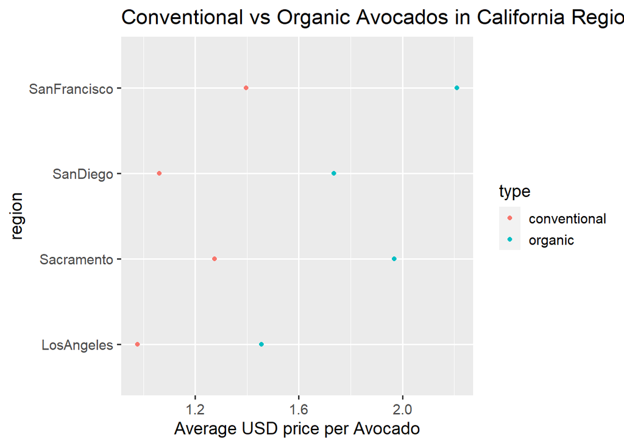

```r
ggplot(data = avocado_avg, mapping = aes(x = mean_price, y = region)) +
  geom_point(aes(color = type)) +
  labs(title = 'Conventional vs Organic Avocados in California Regions', x = 'Average USD price per Avocado') +
  theme_grey(base_size = 14)
```

#I included code output to confirm the summary statistics I mentioned so that the reader does not have to access the data set in order to see the answer. I also changed my bar plot to a dot plot to make it clearer that we are working with quantitative variables.

6. The price difference between conventional and organic avocados is the largest in San Francisco. The price difference is about 81.4 cents.

7. The following plot shows, for all four California regions, the proportion of the mean Hass avocado sales that are small, large, or extra large; conventional vs. organic. Recreate the plot.

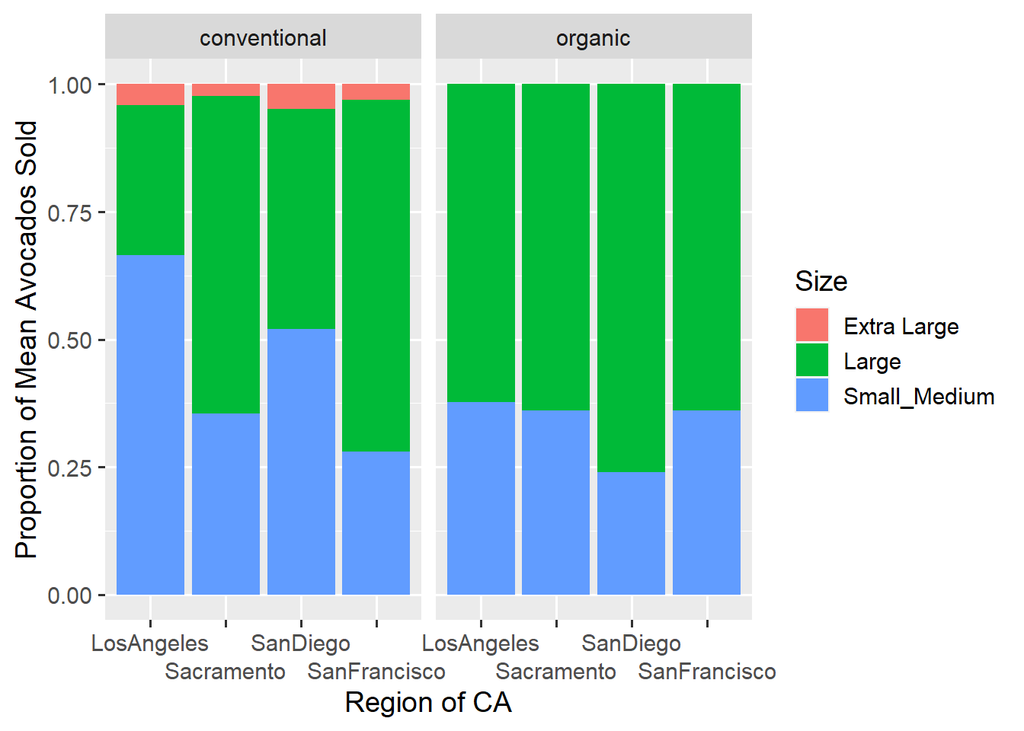

```r
avocado_cali_size <- avocado_cali |>
  select(c('Small_Medium', 'Large', 'Extra Large', 'type', 'region')) |>
  pivot_longer(Small_Medium : `Extra Large`,
               names_to = "Size",
               values_to = "Volume") |>
  group_by(region, Size, type) |>
  summarise(volume_sold = sum(Volume))

ggplot(data = avocado_cali_size,
       mapping = aes(x = region, y = volume_sold, fill = Size)) +
  geom_col(position = "fill") +
  facet_wrap(. ~ type) +
  scale_x_discrete(guide = guide_axis(n.dodge = 2)) +
  labs(x = "Region of CA", y = "Proportion of Mean Avocados Sold") +
  theme_grey(base_size = 14)
```